# Exploratory Data Analysis for the Japanese Beetle Dashboard

Rebecca Rosette Nanfuka

2026-03-13

# 1 Introduction

This report explores the GBIF occurrence dataset used in the Japanese Beetle Tracker project. The goal of the analysis is to confirm that the data can support the dashboard’s core filters and outputs in the Shiny for R application.

The EDA is centered on the following user story:

> As a frequent iNaturalist user, I want to see the impacts of my, and my fellow citizen scientists, observations, so I can filter observations by basis of record.

The key questions for this analysis are:

1. Is the `basisOfRecord` field populated well enough to use as a dashboard filter?
2. How are observations distributed across time and geography?
3. Does the dataset contain enough information to support visual summaries and a map?

# 2 Setup

```r
beetles <- read_tsv("../data/raw/gbif-beetle.csv", show_col_types = FALSE) |>
  mutate(
    year = as.integer(year),
    month = as.integer(month),
    decimalLatitude = as.numeric(decimalLatitude),
    decimalLongitude = as.numeric(decimalLongitude),
    basisOfRecord = na_if(basisOfRecord, ""),
    countryCode = na_if(countryCode, ""),
    stateProvince = na_if(stateProvince, ""),
    species = na_if(species, "")
  )

glimpse(beetles)
```

```
## Rows: 53,557
## Columns: 50
## $ gbifID                           <dbl> 5225231423, 5225208455, 5225203416, 5~
## $ datasetKey                       <chr> "9a0b66df-7535-4f28-9f4e-5bc11b8b096c~
## $ occurrenceID                     <chr> "Natuurpunt:Waarnemingen:363460985", ~
## $ kingdom                          <chr> "Animalia", "Animalia", "Animalia", "~
## $ phylum                           <chr> "Arthropoda", "Arthropoda", "Arthropo~
## $ class                            <chr> "Insecta", "Insecta", "Insecta", "Ins~
## $ order                            <chr> "Coleoptera", "Coleoptera", "Coleopte~
## $ family                           <chr> "Scarabaeidae", "Scarabaeidae", "Scar~
## $ genus                            <chr> "Popillia", "Popillia", "Popillia", "~
## $ species                          <chr> "Popillia japonica", "Popillia japoni~
## $ infraspecificEpithet             <lgl> NA, NA, NA, NA, NA, NA, NA, NA, NA, N~
## $ taxonRank                        <chr> "SPECIES", "SPECIES", "SPECIES", "SPE~
## $ scientificName                   <chr> "Popillia japonica Newman, 1838", "Po~
```

[output cut: 37 more lines]

```r
dim(beetles)
```

```
## [1] 53557    50
```

# 3 Dataset Overview

The file contains GBIF occurrence records for Japanese beetle observations and related specimen records. It includes taxonomic information, geographic coordinates, dates, and record metadata used by the dashboard.

## 3.1 Relevant Columns

| Header | Description | Data Type |
| --- | --- | --- |
| `gbifID` | Unique GBIF occurrence identifier | numeric |
| `species` | Scientific species name | text |
| `countryCode` | Two-letter country code | text |
| `stateProvince` | State or province of the observation | text |
| `eventDate` | Date the observation or record occurred | date/text |
| `month` | Observation month | numeric |
| `year` | Observation year | numeric |
| `basisOfRecord` | Record type such as human observation or preserved specimen | text |
| `decimalLatitude` | Latitude coordinate | numeric |
| `decimalLongitude` | Longitude coordinate | numeric |
| `recordedBy` | Observer or collector name | text |
| `institutionCode` | Source institution code | text |

## 3.2 Initial Summary

```r
summary(beetles[, c("species", "countryCode", "stateProvince", "basisOfRecord", "year", "month")])
```

```
##    species          countryCode        stateProvince      basisOfRecord
##  Length:53557       Length:53557       Length:53557       Length:53557
##  Class :character   Class :character   Class :character   Class :character
##  Mode  :character   Mode  :character   Mode  :character   Mode  :character
##
##
##
##       year          month
##  Min.   :1917   Min.   : 1.000
##  1st Qu.:2020   1st Qu.: 7.000
##  Median :2022   Median : 7.000
##  Mean   :2021   Mean   : 7.189
##  3rd Qu.:2024   3rd Qu.: 8.000
##  Max.   :2026   Max.   :12.000
```

# 4 Data Quality Checks

These checks focus on the fields used directly in the dashboard filters and outputs.

```r
quality_summary <- tibble(
  field = c("basisOfRecord", "year", "countryCode", "decimalLatitude/decimalLongitude"),
  missing_count = c(
    sum(is.na(beetles$basisOfRecord)),
    sum(is.na(beetles$year)),
    sum(is.na(beetles$countryCode)),
    sum(is.na(beetles$decimalLatitude) | is.na(beetles$decimalLongitude))
  )
) |>
  mutate(missing_pct = percent(missing_count / nrow(beetles), accuracy = 0.1))

quality_summary
```

```
## # A tibble: 4 x 3
##   field                            missing_count missing_pct
##   <chr>                                    <int> <chr>
## 1 basisOfRecord                                0 0.0%
## 2 year                                         0 0.0%
## 3 countryCode                                  0 0.0%
## 4 decimalLatitude/decimalLongitude             0 0.0%
```

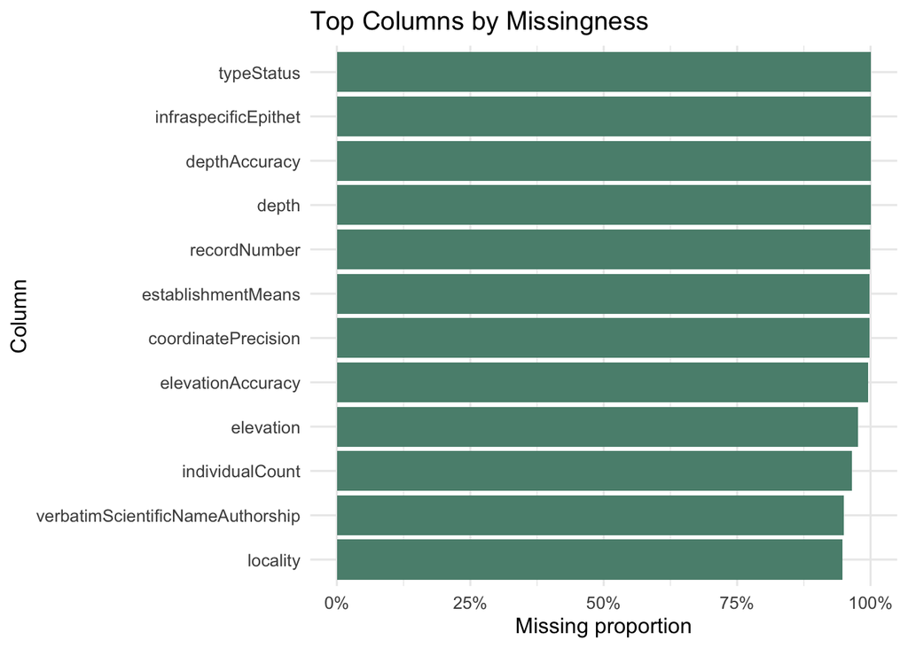

```r
missing_df <- colMeans(is.na(beetles)) |>
  sort(decreasing = TRUE) |>
  enframe(name = "column", value = "missing_prop") |>
  filter(missing_prop > 0) |>
  slice_head(n = 12)

ggplot(missing_df, aes(x = reorder(column, missing_prop), y = missing_prop)) +
  geom_col(fill = "#5b8e7d") +
  coord_flip() +
  scale_y_continuous(labels = percent_format()) +
  labs(
    title = "Top Columns by Missingness",
    x = "Column",
    y = "Missing proportion"
  ) +
  theme_minimal(base_size = 12)
```

# 5 Basis of Record Analysis

This section directly addresses the assignment user story by examining whether `basisOfRecord` is populated and useful as a filter.

```r
basis_summary <- beetles |>
  filter(!is.na(basisOfRecord)) |>
  count(basisOfRecord, sort = TRUE, name = "observations") |>
  mutate(share = observations / sum(observations))

basis_summary
```

```
## # A tibble: 4 x 3
##   basisOfRecord      observations    share
##   <chr>                     <int>    <dbl>
## 1 HUMAN_OBSERVATION         50419 0.941
## 2 PRESERVED_SPECIMEN         2965 0.0554
## 3 MATERIAL_SAMPLE             164 0.00306
## 4 OCCURRENCE                    9 0.000168
```

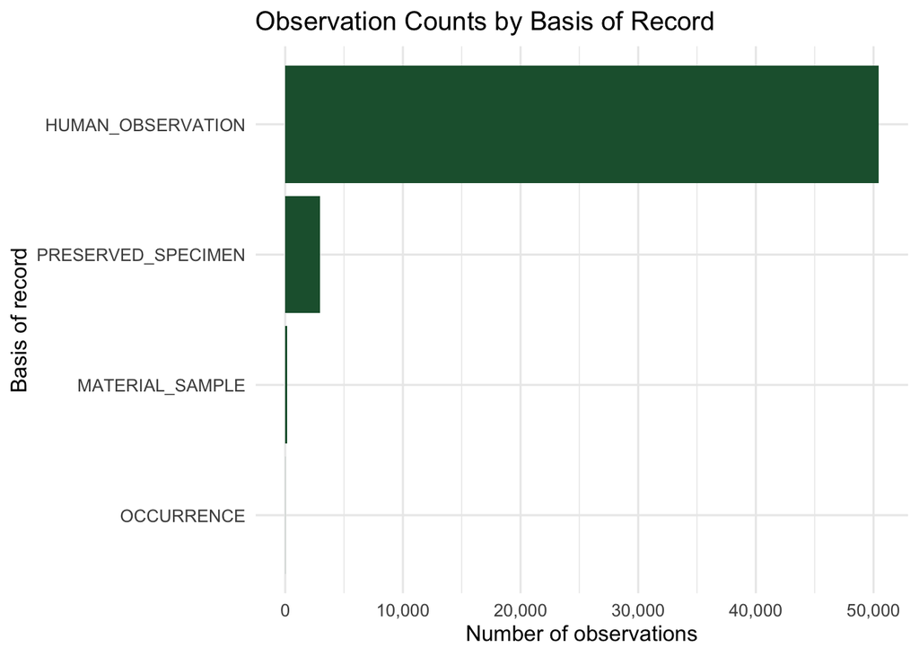

```r
ggplot(basis_summary, aes(x = reorder(basisOfRecord, observations), y = observations)) +
  geom_col(fill = "#1f5f3b") +
  coord_flip() +
  scale_y_continuous(labels = comma_format()) +
  labs(
    title = "Observation Counts by Basis of Record",
    x = "Basis of record",
    y = "Number of observations"
  ) +
  theme_minimal(base_size = 12)
```

The `basisOfRecord` field is well suited for a dashboard filter because it is populated for most records and separates human observations from other record sources such as preserved specimens.

# 6 Temporal Patterns

The dashboard includes time-based outputs, so it is important to confirm the dataset supports yearly and seasonal summaries.

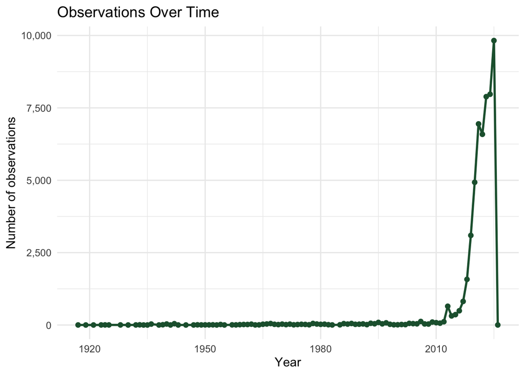

```r
yearly_counts <- beetles |>
  filter(!is.na(year)) |>
  count(year, name = "observations")

ggplot(yearly_counts, aes(x = year, y = observations)) +
  geom_line(color = "#1f5f3b", linewidth = 1) +
  geom_point(color = "#1f5f3b", size = 1.8) +
  scale_y_continuous(labels = comma_format()) +
  labs(
    title = "Observations Over Time",
    x = "Year",
    y = "Number of observations"
  ) +
  theme_minimal(base_size = 12)
```

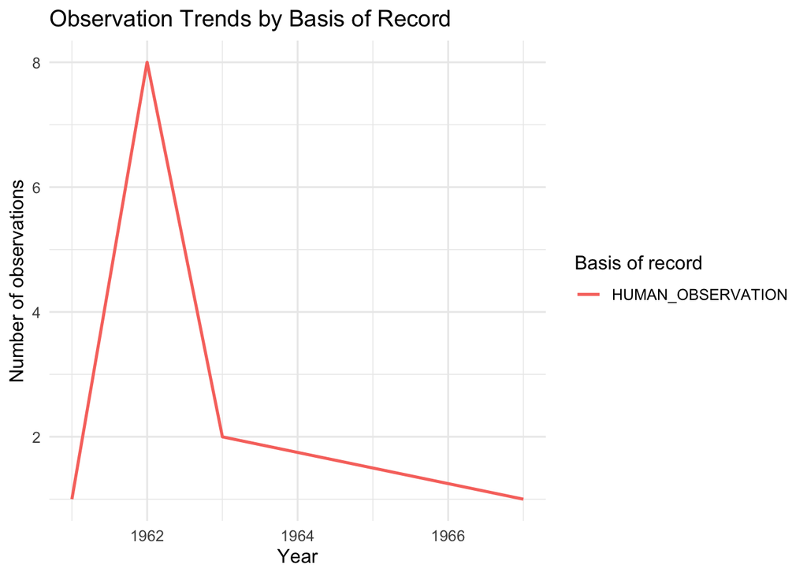

```r
year_basis <- beetles |>
  filter(!is.na(year), !is.na(basisOfRecord)) |>
  count(year, basisOfRecord, name = "observations") |>
  group_by(basisOfRecord) |>
  mutate(total_basis = sum(observations)) |>
  ungroup() |>
  slice_max(order_by = total_basis, n = 4, with_ties = FALSE)

ggplot(year_basis, aes(x = year, y = observations, color = basisOfRecord)) +
  geom_line(linewidth = 0.9) +
  labs(
    title = "Observation Trends by Basis of Record",
    x = "Year",
    y = "Number of observations",
    color = "Basis of record"
  ) +
  theme_minimal(base_size = 12)
```

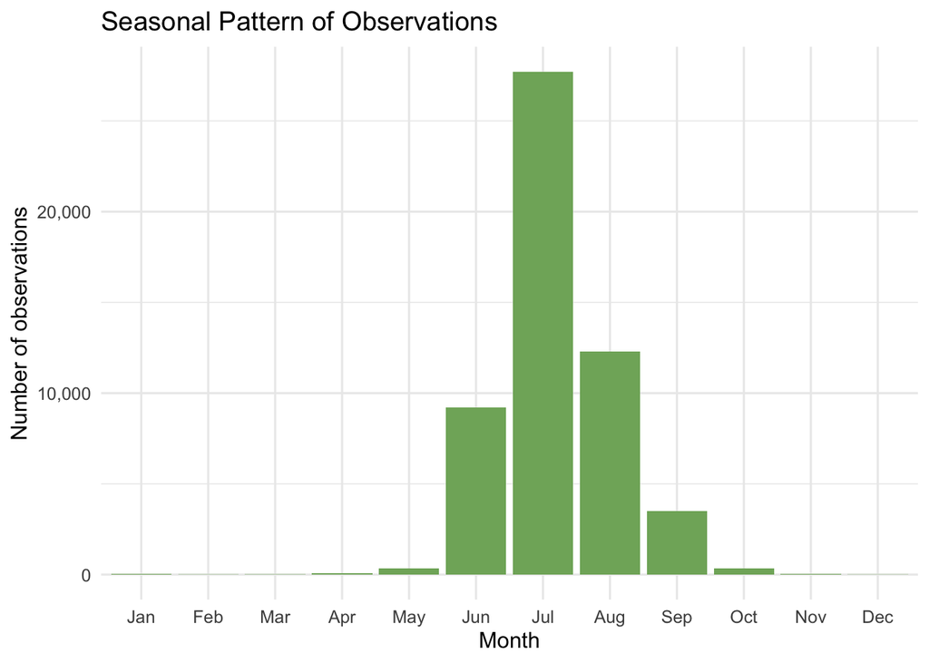

```r
month_levels <- c("Jan", "Feb", "Mar", "Apr", "May", "Jun",
                  "Jul", "Aug", "Sep", "Oct", "Nov", "Dec")

monthly_counts <- beetles |>
  filter(!is.na(month), month >= 1, month <= 12) |>
  count(month, name = "observations") |>
  mutate(month_label = factor(month_levels[month], levels = month_levels))

ggplot(monthly_counts, aes(x = month_label, y = observations)) +
  geom_col(fill = "#7fb069") +
  scale_y_continuous(labels = comma_format()) +
  labs(
    title = "Seasonal Pattern of Observations",
    x = "Month",
    y = "Number of observations"
  ) +
  theme_minimal(base_size = 12)
```

The dataset supports both long-term and seasonal summaries, which aligns well with the app’s time-series outputs.

# 7 Geographic Patterns

The dashboard also depends on country, region, and coordinate data for spatial summaries.

```r
top_countries <- beetles |>
  filter(!is.na(countryCode)) |>
  count(countryCode, sort = TRUE, name = "observations") |>
  slice_head(n = 10)

top_countries
```

```
## # A tibble: 9 x 2
##   countryCode observations
##   <chr>              <int>
## 1 US                 37351
## 2 CA                 12959
## 3 IT                  1449
## 4 JP                  1359
## 5 PT                   190
## 6 CH                   130
## 7 RU                   105
## 8 BE                    10
## 9 DE                     4
```

```r
top_regions <- beetles |>
  filter(!is.na(stateProvince)) |>
  count(stateProvince, sort = TRUE, name = "observations") |>
  slice_head(n = 10)

top_regions
```

```
## # A tibble: 10 x 2
##    stateProvince    observations
##    <chr>                   <int>
##  1 "Ontario"                8503
##  2 "Qu\u00e9bec"            2966
##  3 "New York"               2834
##  4 "Colorado"               2362
##  5 "Illinois"               2261
##  6 "Pennsylvania"           2239
##  7 "Virginia"               2207
##  8 "Michigan"               2099
##  9 "Ohio"                   2082
## 10 "North Carolina"         1958
```

```r
map_data <- beetles |>
  filter(
    !is.na(decimalLatitude),
    !is.na(decimalLongitude),
    between(decimalLatitude, -90, 90),
    between(decimalLongitude, -180, 180)
  ) |>
  slice_head(n = 2000)

leaflet(map_data) |>
  addProviderTiles(providers$CartoDB.Positron) |>
  addCircleMarkers(
    lng = ~decimalLongitude,
    lat = ~decimalLatitude,
    radius = 3,
    stroke = FALSE,
    fillOpacity = 0.5,
    color = "#1f5f3b",
    popup = ~paste0(
      "<strong>Species:</strong> ", ifelse(is.na(species), "Unknown", species),
      "<br><strong>Country:</strong> ", ifelse(is.na(countryCode), "Unknown", countryCode),
      "<br><strong>Region:</strong> ", ifelse(is.na(stateProvince), "Unknown", stateProvince),
      "<br><strong>Year:</strong> ", ifelse(is.na(year), "Unknown", year),
      "<br><strong>Basis of record:</strong> ", ifelse(is.na(basisOfRecord), "Unknown", basisOfRecord)
    )
  )
```

[interactive chart not shown]

# 8 Conclusion

This EDA confirms that the GBIF dataset is appropriate for the Japanese Beetle Tracker dashboard in Shiny for R.

The main findings are:

1. `basisOfRecord` is populated well enough to serve as a meaningful dashboard filter.
2. The dataset supports reactive summaries by year, month, country, and region.
3. There are sufficient valid coordinates to power an interactive map.

Overall, the data structure aligns with the app requirements and supports the core functionality implemented in the dashboard.